## Linear Regression of Interhouse Swipes with Month, Year, and House

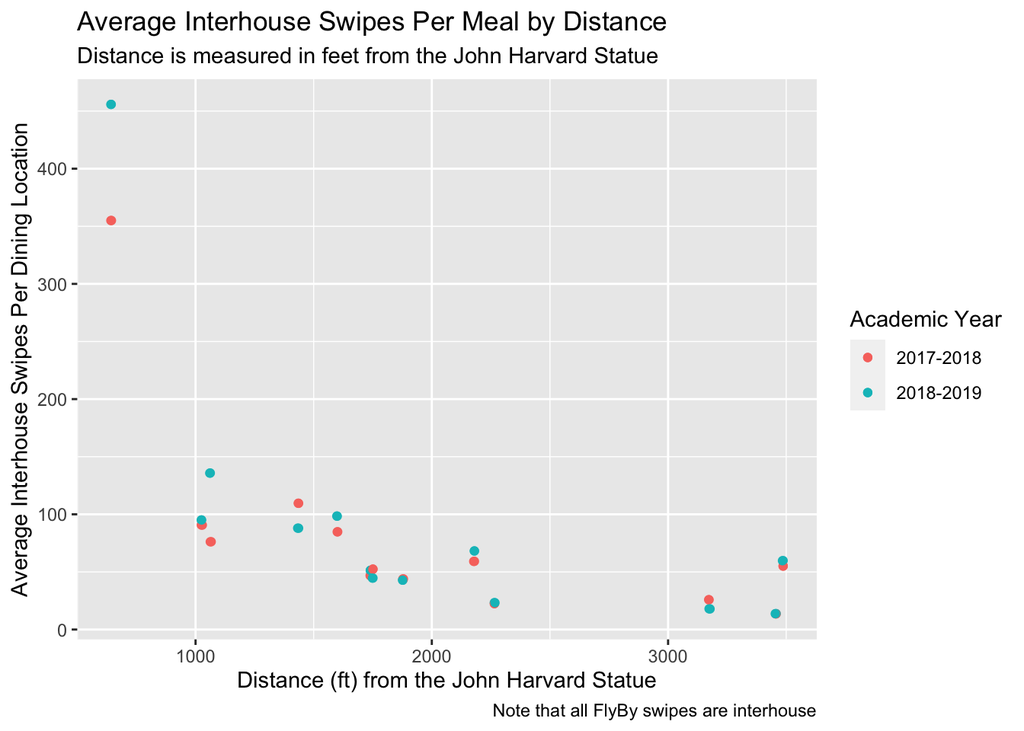

You can see that between the two academic years, the houses closest to the John Harvard Statue experienced a surge in the number of interhouse swipes relative to the previous academic year. This likely occurred as a result of increased time pressure due to the schedule change.

Another point worth noting is that FlyBy is a huge outlier on this plot. Because FlyBy is not a house, all student swipes are counted as interhouse. For that reason, I will exclude FlyBy from my regression.

We see that distance and year appear to have an association with average number of interhouse swipes. I will run a regression to estimate the average treatment effect of house and month on the average number of interhouse swipes.

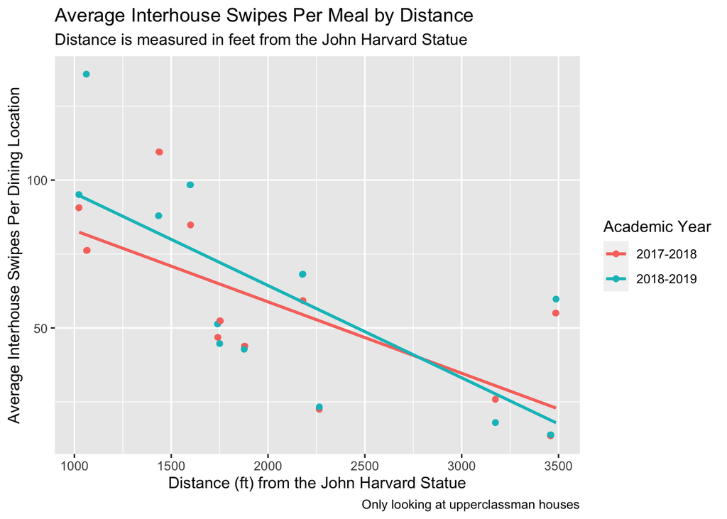

I began my investigation to best explain the variables behind interhouse swipe counts by building multiple linear models and assessing the efficacy of each. For example, the above plot is of a linear regression of average interhouse swipes on distance; this model only accounts for about 44% of the variation in the data. I found that a model looking at each house and controlling for the month and academic year best explains the variation in interhouse swipe counts. My linear model explains just over 79% of variation present in the data. Considering that this data does not provide any variables to quantify social connectivity between houses, such as students dining with friends in other houses, 79% explanation captures our data very well.

The below graph displays the estimated interhouse swipe counts per meal at each house, controlling for month and academic year. Each point represents the average count of interhouse swipes at each meal for that respective house, while the error bars represent the lower and upper bounds of our 95% confidence intervals. We are 95% confident that the true average number of interhouse swipes for each month is captured within our error bars.

When the error bars between houses do not overlap along the x-axis, that means that the difference in the average number of interhouse swipe counts per meal is statistically significant. That is, we are 95% confident that the true number of interhouse swipe counts per meal is different between the houses when controlling for month. For example, Lowell, Quincy, Adams, and Winthrop do not overlap with any of the remaining 8 houses. They have a significantly greater number of interhouse swipes per meal compared to the other houses when controlling for month.

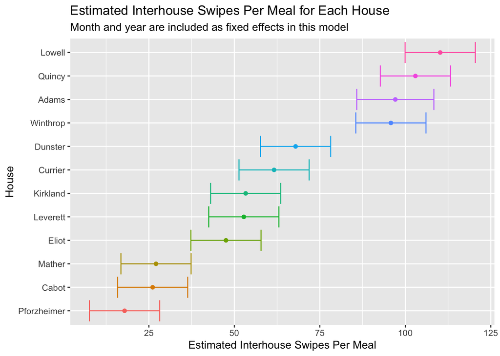

While the above plot shows the average interhouse swipe counts for each house while controlling for month, the below plot displays the estimated interhouse swipe counts per meal associated with each month while controlling for house.

As we can see, all months have some overlap between the error bars, so there is not a statistically significant difference between the interhouse swipe counts and any two months. However, we can see that January of 2019, on average, experience the greatest number of interhouse swipe counts while December of 2017 saw the least.

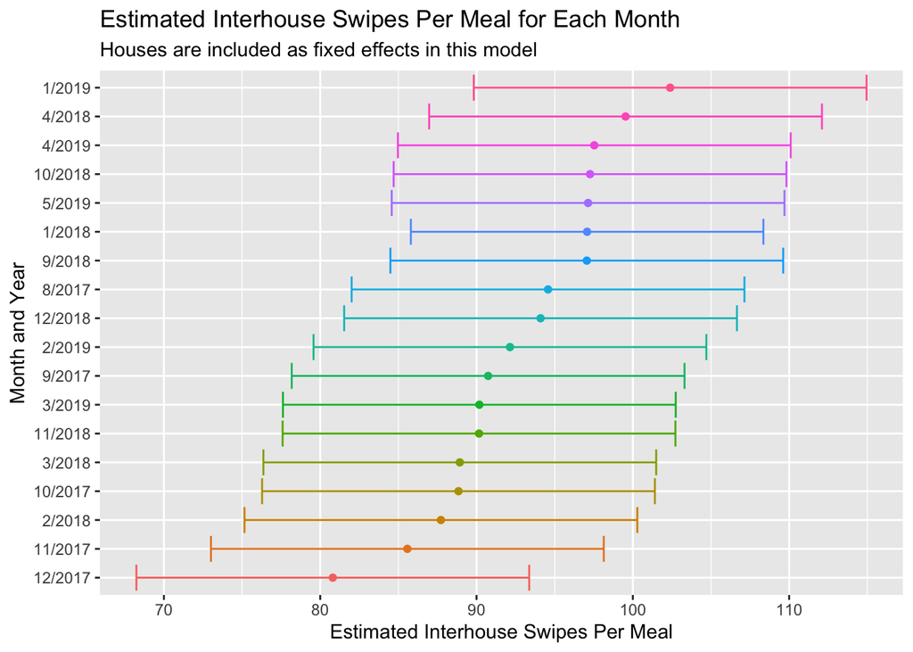